# Visualizing and Maintaining the Green Canopy of NYC

Author

Sebastian Alejos

Published

November 15, 2025

# Downloading and Transforming NYC City Council District Boundaries

The output below shows District identifiers shuch as CounDist (Council District), Shape_Leng (Perimeter length of the district boundary), Shape_Area (area of the district in square feet), and geometry (atcual polygon coordinates).

```
Simple feature collection with 6 features and 3 fields
Geometry type: MULTIPOLYGON
Dimension:     XY
Bounding box:  xmin: 975219.2 ymin: 149419.9 xmax: 1021926 ymax: 220109.1
Projected CRS: NAD83 / New York Long Island (ftUS)
  CounDist Shape_Leng Shape_Area                       geometry
1        3   81955.34   76316715 MULTIPOLYGON (((985271.2 21...
2       38  177740.22  151736801 MULTIPOLYGON (((986291.3 17...
3       43   58169.11   75477512 MULTIPOLYGON (((984119.7 17...
4       46  254186.11  277477723 MULTIPOLYGON (((1006493 157...
5       25   47289.03   63861368 MULTIPOLYGON (((1015113 217...
6       36   39108.36   76224392 MULTIPOLYGON (((1004205 191...
```

# Downloading Tree Data Points Responsibly

# Plotting all Tree Points

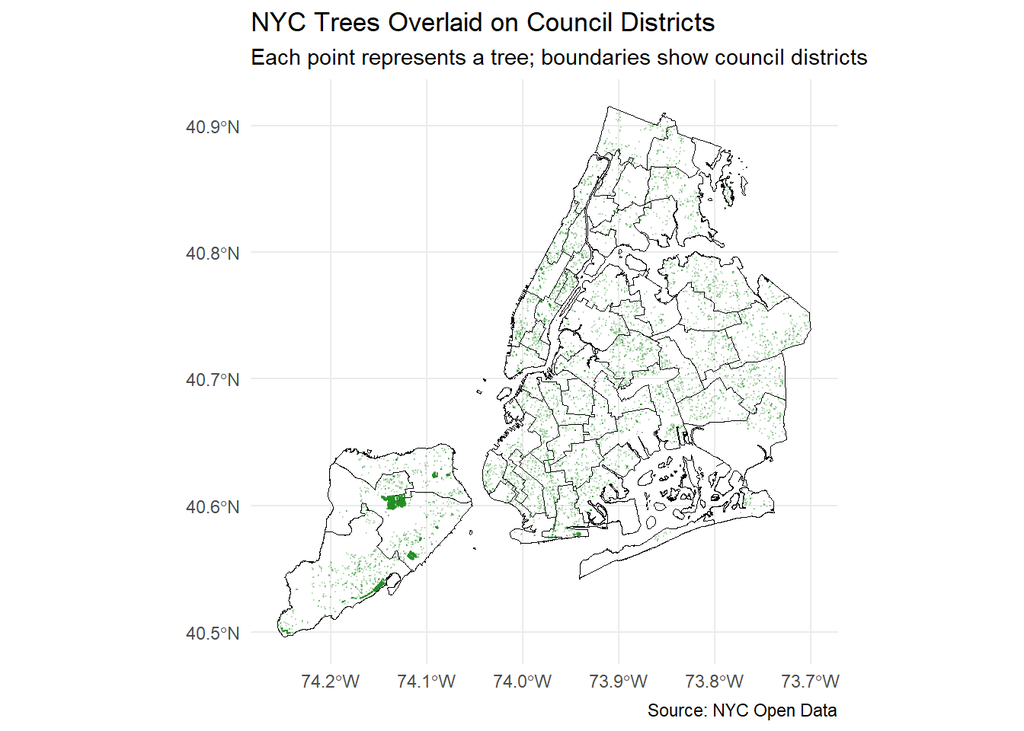

# District Level Analyses on Trees

```
Simple feature collection with 1 feature and 2 fields
Geometry type: MULTIPOINT
Dimension:     XY
Bounding box:  xmin: -74.19012 ymin: 40.55576 xmax: -74.00917 ymax: 40.62469
Geodetic CRS:  WGS 84
  CounDist tree_count                       geometry
1       50       2356 MULTIPOINT ((-74.02614 40.6...
```

## Q2: The Council District 50 with the shape area of 665199996 has the most tree density of 3.541792e-06.

```
Simple feature collection with 1 feature and 4 fields
Geometry type: MULTIPOINT
Dimension:     XY
Bounding box:  xmin: -74.19012 ymin: 40.55576 xmax: -74.00917 ymax: 40.62469
Geodetic CRS:  WGS 84
  CounDist tree_count Shape_Area tree_density                       geometry
1       50       2356  665199996 3.541792e-06 MULTIPOINT ((-74.02614 40.6...
```

## Q3. District 15 has the highest fraction of dead trees with respect to all the districts.

```
# A tibble: 1 × 4
  CounDist total_trees dead_trees dead_fraction
     <int>       <int>      <int>         <dbl>
1       15          20         10           0.5
```

## Q4. The most common tree species in Manhattan is Gleditsia triacanthos var. inermis - Thornless honeylocust.

```
Simple feature collection with 1 feature and 2 fields
Geometry type: MULTIPOINT
Dimension:     XY
Bounding box:  xmin: -74.01077 ymin: 40.70639 xmax: -73.9141 ymax: 40.86867
Geodetic CRS:  WGS 84
                                                genusspecies   n
1 Gleditsia triacanthos var. inermis - Thornless honeylocust 240
                        geometry
1 MULTIPOINT ((-73.99301 40.7...
```

## Q5. The closest tree species to Baruch College Campus is “Pyrus calleryana - Callery pear”.

```
[1] "Pyrus calleryana - Callery pear"
```

# Government Project Design

Proposal: Forest Hills Trees Renewal & Resilience Program

Forest Hills (District 29) represents the optimal balance of need and opportunity. Unlike districts with sparse canopy or existing healthy forests, our neighborhood faces elevated mortality and stump hazards within a dense, historic canopy. Targeted investment here will deliver visible safety improvements and restore neighborhood character — making District 29 the most impactful choice for discretionary tree funding.

Forest Hills is known for its leafy and historic charm- but recent data shows a troubling rise in tree mortality and stump accumulation. This initiative will restore the neighborhood’s green infrastructure while preparing it for tree friendly future.

## Quantitative Scope of the Project

Replacement of 250 residual stumps with new plantings in high-foot-traffic areas.

Planting of 1,200 new trees, prioritizing resilient species such as Ginkgo biloba, Quercus bicolor (Swamp White Oak), and Celtis occidentalis (Hackberry).

Maintenance of 1,500 existing trees with elevated to prevent limb failure and improve public safety.